### Part II

#### Solution

**1.** An industrial psychologist working for a large corporation designs a study to evaluate the effect of background music on the typing efficiency of secretaries. The psychologist selects a random sample of seven secretaries from the secretarial pool. Each subject is exposed to three types of background music: no music, classical music, and hard rock music. The subject is given a standard typing test that combines an assessment of speed with a penalty for typing errors. The particular order of the three experiments is randomized for each of the seven subjects. The results are given here with a high score indicating a superior performance. The data are contained in the file `music.txt`.

1. What is the name of this design? List all the factors and their types (treatment or block factor). Are there any random factors? If yes, identify them.  
   **Solution**  
   This is a randomized (complete) block design. Factors are “music type” and “subject.” Music type is a treatment factor and subject is a block factor. The subject is a random factor.
2. Write down the statistical model of this design, including assumptions, and define every term clearly.  
   **Solution**  
   Unrestricted mixed model: $y_{ij} = \mu + \alpha_i + \beta_j + \varepsilon_{ij}, \ \ \ i=1,2,3 \ \text{and} \ j=1, \dots, 7$
- $y_{ij}$ is the score on the $j^{th}$ subject hearing the $i^{th}$ music type.
- $\alpha_i$ is the $i^{th}$ music type effect.
- $\beta_j$ is the $j^{th}$ subject effect.

and

- the error $\varepsilon_{ij} \stackrel{iid}{\sim} N(0, \sigma^2)$
- $\alpha_3 =0$
- $\beta_j \stackrel{iid}{\sim} N(0, \sigma_b^2)$
- $\varepsilon_{ij}$ and $\beta_j$ are independent.
3. Suppose that the assumptions are satisfied. Can you conclude that there are significant differences in the mean typing efficiency for the three types of music? Use a significance level of $0.05$.  
   **Solution**

```r
raw.text <- "
'Subject'   'TypeMusic' 'TypingEfficiency'
1   'NoMusic'   20
2   'NoMusic'   17
3   'NoMusic'   24
4   'NoMusic'   20
5   'NoMusic'   22
6   'NoMusic'   25
7   'NoMusic'   18
1   'HardRock'  20
2   'HardRock'  18
3   'HardRock'  23
4   'HardRock'  18
5   'HardRock'  21
6   'HardRock'  22
7   'HardRock'  19
1   'Classical' 24
2   'Classical' 20
3   'Classical' 27
4   'Classical' 22
5   'Classical' 24
6   'Classical' 28
7   'Classical' 16
"
typing.df <- read.table(header=TRUE, text=raw.text)
typing.df$Subject <- factor(typing.df$Subject)
```

$H_0: \alpha_1 = \alpha_2 = \alpha_3 = 0$  
$H_a:$ at least one $\alpha_i \neq 0$.  
T.S.:

```r
typing.aov <- aov(formula=TypingEfficiency ~ Subject + TypeMusic, data=typing.df)
summary(typing.aov)
```

```
##             Df Sum Sq Mean Sq F value   Pr(>F)
## Subject      6 149.33  24.889  10.523 0.000346 ***
## TypeMusic    2  30.95  15.476   6.544 0.011978 *
## Residuals   12  28.38   2.365
## ---
## Signif. codes:  0 '***' 0.001 '**' 0.01 '*' 0.05 '.' 0.1 ' ' 1
```

The *p*-value is 0.012, which is less than 0.05. Therefore, we reject the null hypothesis. There is an effect of the type of music on typing efficiency.

4. Use a multiple comparison procedure to determine which of the three music types have different mean typing efficiency, controlling the familywise error rate at $0.10$.  
   **Solution**

```r
TukeyHSD(x=typing.aov, which="TypeMusic", conf.level=0.90)
```

```
##   Tukey multiple comparisons of means
##     90% family-wise confidence level
##
## Fit: aov(formula = TypingEfficiency ~ Subject + TypeMusic, data = typing.df)
##
## $TypeMusic
##                          diff       lwr        upr     p adj
## HardRock-Classical -2.8571429 -4.719483 -0.9948022 0.0118007
## NoMusic-Classical  -2.1428571 -4.005198 -0.2805165 0.0556533
## NoMusic-HardRock    0.7142857 -1.148055  2.5766263 0.6691167
```

Can’t figure out why the results don’t match solutions.

An alternative:

```r
library(agricolae)
tukey.pair <- HSD.test(y=typing.aov, trt="TypeMusic", alpha=0.10)
tukey.pair$groups
```

```
##         trt    means M
## 1 Classical 23.00000 a
## 2 NoMusic   20.85714 b
## 3 HardRock  20.14286 b
```

5. Verify the assumptions of part (b) by graphs. If assumptions are not all satisfied, explain the possible reason behind.  
   **Solution**  
   “The errors are independent and normally distributed with constant variance. The random sample of subjects ensures independence. To check for normality and constant variances, make the following residuals plots.”

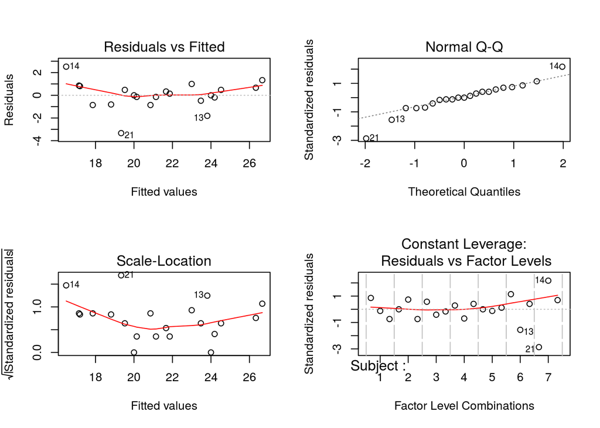

```r
par(mfrow=c(2,2))
# Automatically-generated plot
plot(x=typing.aov)
```

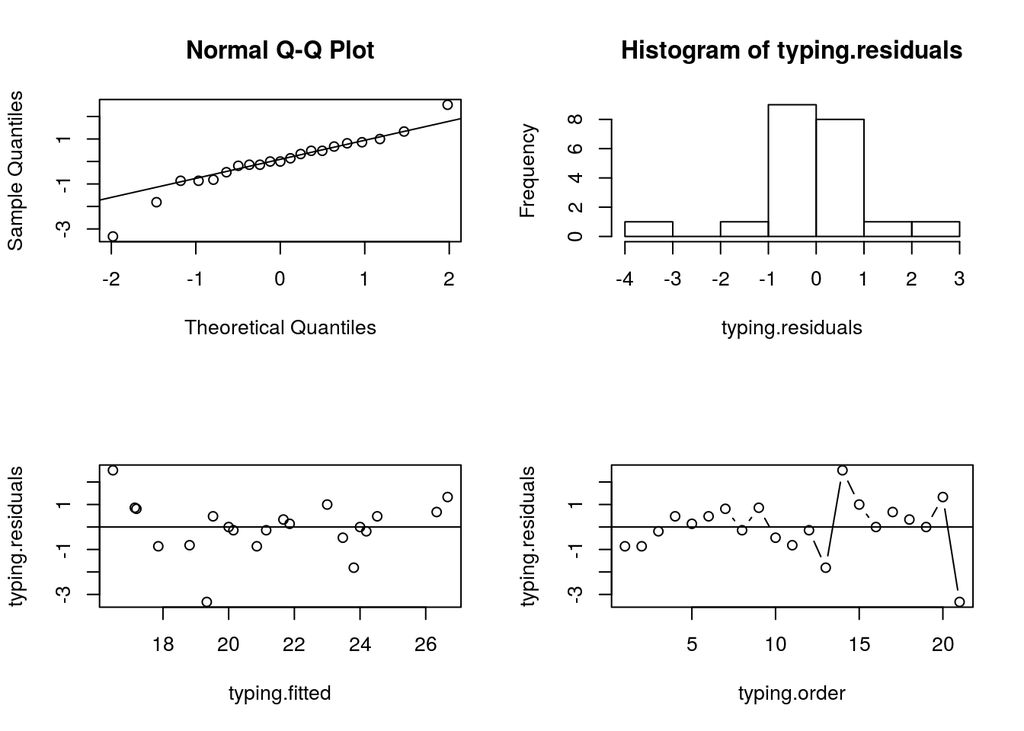

```r
# Plots that match the solutions
# plot 1
typing.residuals <- resid(object=typing.aov)
qqnorm(y=typing.residuals)
qqline(y=typing.residuals)

# plot 2
hist(x=typing.residuals)

# plot 3
typing.fitted <- fitted(object=typing.aov)
plot(x=typing.fitted, y=typing.residuals)
abline(h=0)

# plot 4
typing.order <- 1:nrow(typing.df)
plot(x=typing.order, y=typing.residuals, type='b')
abline(h=0)
```

“Besides two outliers (residuals outside of (-2, 2)), the normal probability plot shows more or less following a line, indicating normality seems fine; the residual vs. fitted value shows no pattern excluding outliers, indicating constant variance seems fine. However, there are an extreme outlier and a mild outlier indicating the lack of fit of this model. The possible reason could be the existence of the interaction effect between music types and subjects on the typing efficiency. While most secretaries are affected by background music, a few of them may not be affected much.”

See solutions for output titled, “Unusual Observations for efficiency.”